DS 6030 | Fall 2024 | University of Virginia

# Homework #3: Penalized Regression

Author

**Alex Yang**

Published

September 26, 2024

# Required R packages and Directories

```r
data_dir = 'https://mdporter.github.io/teaching/data/' # data directory
library(mlbench)
library(glmnet)
library(tidymodels)# for optional tidymodels solutions
library(tidyverse) # functions for data manipulation
```

# Problem 1: Optimal Tuning Parameters

In cross-validation, we discussed choosing the tuning parameter values that minimized the cross-validation error. Another approach, called the “one-standard error” rule [ISL pg 214, ESL pg 61], uses the values corresponding to the least complex model whose cv error is within one standard error of the best model. The goal of this assignment is to compare these two rules.

Use simulated data from `mlbench.friedman1(n, sd=2)` in the `mlbench` R package to fit *lasso models*. The tuning parameter $\lambda$ (corresponding to the penalty on the coefficient magnitude) is the one we will focus one. Generate training data, use k-fold cross-validation to get $\lambda_{\rm min}$ and $\lambda_{\rm 1SE}$, generate test data, make predictions for the test data, and compare performance of the two rules under a squared error loss using a hypothesis test.

Choose reasonable values for:

- Number of cv folds ($K$)
  - Note: you are free to use repeated CV, repeated hold-outs, or bootstrapping instead of plain cross-validation; just be sure to describe what do did so it will be easier to follow.
- Number of training and test observations
- Number of simulations
- If everyone uses different values, we will be able to see how the results change over the different settings.
- Don’t forget to make your results reproducible (e.g., set seed)

This pseudo code (using k-fold cv) will get you started:

```yaml
library(mlbench)
library(glmnet)

#-- Settings
n_train =        # number of training obs
n_test =         # number of test obs
K =              # number of CV folds
alpha =          # glmnet tuning alpha (1 = lasso, 0 = ridge)
M =              # number of simulations

#-- Data Generating Function
getData <- function(n) mlbench.friedman1(n, sd=2) # data generating function

#-- Simulations
# Set Seed Here

for(m in 1:M) {

# 1. Generate Training Data
# 2. Build Training Models using cross-validation, e.g., cv.glmnet()
# 3. get lambda that minimizes cv error and 1 SE rule
# 4. Generate Test Data
# 5. Predict y values for test data (for each model: min, 1SE)
# 6. Evaluate predictions

}

#-- Compare
# compare performance of the approaches / Statistical Test
```

## a. Code for the simulation and performance results

**Solution**

```r
library(glmnet)

#-- Settings
n_train =150       # number of training obs
n_test = 50        # number of test obs
K = 10             # number of CV folds
alpha = 1         # glmnet tuning alpha (1 = lasso, 0 = ridge)
M = 100           # number of simulations

#-- Data Generating Function
getData <- function(n) {
  temp_data <- mlbench.friedman1(n, sd=2)
  x <- as.data.frame(temp_data$x)
  y <- temp_data$y
  list(x=x, y=y)
}

#-- Simulations
set.seed(123)

# generate results to store results
results <- tibble(
  min_rmse = numeric(M),
  min_1se = numeric(M))

for(m in 1:M) {

# 1. Generate Training Data
  train_data <- getData(n_train)
  x_train <- as.matrix(train_data$x)
  y_train <- train_data$y

# 2. Build Training Models using cross-validation, e.g., cv.glmnet()
  train_model =
    cv.glmnet(x_train,y_train,
              alpha = alpha,
              nfolds = K)

# 3. get lambda that minimizes cv error and 1 SE rule
  lambda_min = train_model$lambda.min
  lambda_1se <- train_model$lambda.1se

# 4. Generate Test Data
  test_data <- getData(n_test)
  x_test <- as.matrix(test_data$x)
  y_test <- test_data$y

# 5. Predict y values for test data (for each model: min, 1SE)
  y_hat_min <- predict(
    train_model,
    newx = x_test,
    s = lambda_min
  )

  y_hat_1se <- predict(
    train_model,
    newx = x_test,
    s = lambda_1se
  )

# 6. Evaluate predictions
  lambda_min_rmse <- sqrt(mean((y_hat_min-y_test)^2))
  lambda_1se_rmse <- sqrt(mean((y_hat_1se-y_test)^2))

# storing results
  results[m, ] <- tibble(
    min_rmse = lambda_min_rmse,
    min_1se = lambda_1se_rmse
  )
}

#-- Compare
model_results <- t.test(
  results$min_rmse, results$min_1se, paired = TRUE
)
print(model_results)
```

```
    Paired t-test

data:  results$min_rmse and results$min_1se
t = -13, df = 99, p-value <2e-16
alternative hypothesis: true mean difference is not equal to 0
95 percent confidence interval:
 -0.226 -0.165
sample estimates:
mean difference
         -0.195
```

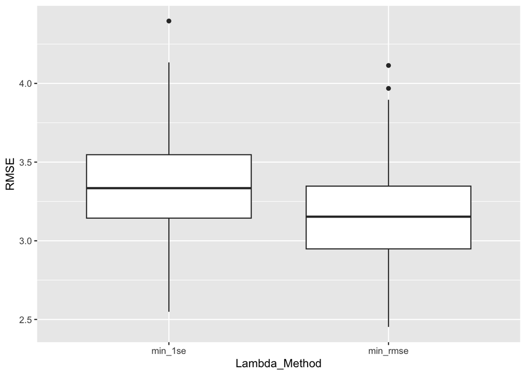

```r
# compare performance of the approaches / Statistical Test
results |>
  pivot_longer(cols = c(min_rmse, min_1se), names_to = "Lambda_Method", values_to = "RMSE") |>
  ggplot(aes(x= Lambda_Method, y= RMSE)) +
  geom_boxplot()
```

## b. Hypothesis test

Provide results and discussion of a hypothesis test comparing $\lambda_{\rm min}$ and $\lambda_{\rm 1SE}$.

**Solution**

from the hypothesis test we can see that the use of lambda_min is better than lambda_1se because the p-value is close to 0 which allows us to reject the hnull hypothesis which states that there is not a difference in terms of RMSE using lambda_min and lambda_1se. The confidence interval which is smaller than zero on both ends also futher supports the argument.

# Problem 2 Prediction Contest: Real Estate Pricing

This problem uses the [realestate-train](https://mdporter.github.io/teaching/data//realestate-train.csv) and [realestate-test](https://mdporter.github.io/teaching/data//realestate-test.csv) (click on links for data).

The goal of this contest is to predict sale price (in thousands) (`price` column) using an *elastic net* model. Evaluation of the test data will be based on the root mean squared error ${\rm RMSE}= \sqrt{\frac{1}{m}\sum_i (y_i - \hat{y}_i)^2}$ for the $m$ test set observations.

## a. Load and pre-process data

Load the data and create necessary data structures for running *elastic net*.

- You are free to use any data transformation or feature engineering
- Note: there are some categorical predictors so at the least you will have to convert those to something numeric (e.g., one-hot or dummy coding).

**Solution**

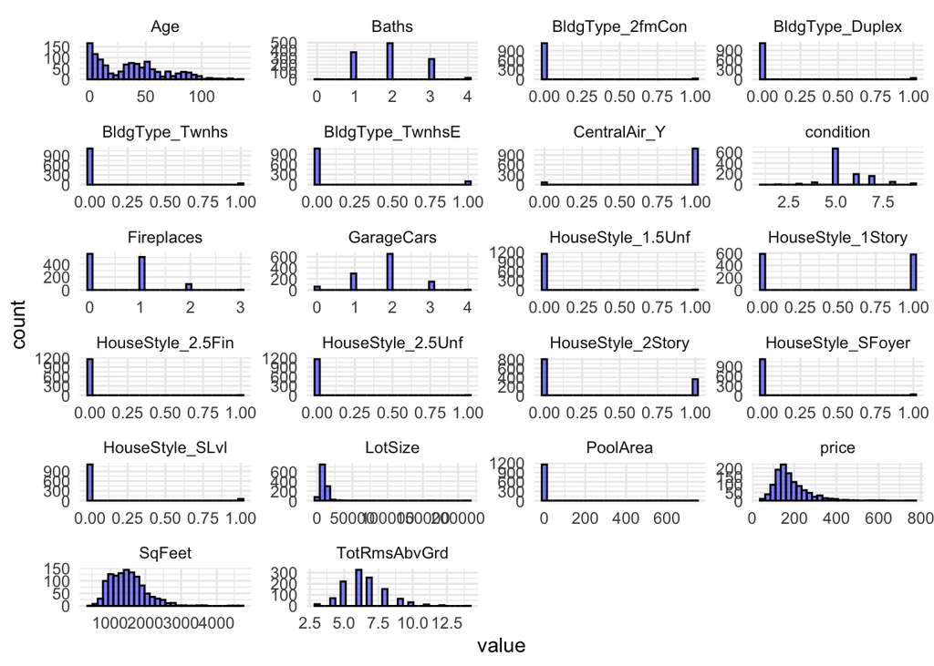

```r
# loading the data
data_dir = 'https://mdporter.github.io/teaching/data/'
train_data <- read_csv(file.path(data_dir, 'realestate-train.csv'))
test_data <- read_csv(file.path(data_dir, 'realestate-test.csv'))
# glimpse(train_data)
# categorical columns
cat_cols <- c('CentralAir', 'BldgType', 'HouseStyle')

library(fastDummies)
# dummy vars change
train_data <- dummy_cols(train_data,
                         select_columns = cat_cols,
                         remove_first_dummy = TRUE,
                         remove_selected_columns = TRUE)

test_data <- dummy_cols(test_data,
                        select_columns = cat_cols,
                        remove_first_dummy = TRUE,
                        remove_selected_columns = TRUE)

# EDA

train_data_long <- train_data %>%
  pivot_longer(cols = everything(), names_to = "variable", values_to = "value")

ggplot(train_data_long, aes(x = value)) +
  geom_histogram(bins = 30, fill = "blue", color = "black", alpha = 0.5) +
  facet_wrap(~ variable, scales = "free", ncol = 4) +
  theme_minimal()
```

```r
# feature engineering
train_data <- train_data |>
  mutate(log_age =log(Age),
         log_sqfeet = log(SqFeet)) |>
  select(-c(Age, SqFeet))

test_data <- test_data |>
  mutate(log_age =log(Age),
         log_sqfeet = log(SqFeet)) |>
  select(-c(Age, SqFeet))

# separate y and x
y_train <- train_data$price|> as.matrix()
x_train<- train_data |> select(-price)|> as.matrix()
x_test <- test_data |> as.matrix()
```

## b. Fit elastic net model

Use an *elastic net* model to predict the `price` of the test data.

- You are free to use any data transformation or feature engineering
- You are free to use any tuning parameters
- Report the $\alpha$ and $\lambda$ parameters you used to make your final predictions.
- Describe how you choose those tuning parameters

**Solution**

```r
library(glmnet)


alpha_values <- seq(0, 1, by=0.1) #loop over alpha values
results <- data.frame(alpha = numeric(), lambda_min = numeric(), lambda_1se = numeric(), cv_mse_optimal = numeric())

set.seed(213)
for (alpha in alpha_values) {
  cv_model <- cv.glmnet(
    x_train, y_train,
    alpha = alpha,
    nfolds = 10,
    type.measure = "mse",
    standardize = TRUE
  )

  results<- rbind(results, data.frame(
    alpha = alpha,
    lambda_min = cv_model$lambda.min,
    lambda_1se = cv_model$lambda.1se,
    cv_mse_optimal = min(cv_model$cvm)
  ))
}

# best alpha and lambda based on lowest cv_mse_optimal
best_outcome <- results |>
  filter(cv_mse_optimal == min(cv_mse_optimal))

best_alpha <- best_outcome$alpha
best_lambda <- best_outcome$lambda_min

best_model <- glmnet(
  x_train, y_train,
  alpha = best_alpha,
  lambda = best_lambda,
  standardize = TRUE
)

cat("Best alpha and lambda are:", best_alpha, "and", best_lambda, "\n")
```

```
Best alpha and lambda are: 0.4 and 0.775
```

I chose the tuning parameters by looping through all the possible alpha values using seq(0,1,step=0.1) and stored all the model outcomes using those values into a dataframe along with the cross-validated smallest mean sqaured error. I then filtered to find out the alpha and lambda that has the smallest cv_mse_optimal to find out the optimal alpha and lambda

## c. Submit predictions

Submit a .csv file (ensure comma separated format) named `lastname_firstname.csv` that includes your predictions in a column named *yhat*. We will use automated evaluation, so the format must be exact.

- You will receive credit for a proper submission; the top five scores will receive 2 bonus points.

**Solution**

```r
y_hat <- predict(best_model, x_test)
submission_df <- data.frame(yhat = y_hat) |>
  rename(yhat = s0)

write.csv(submission_df, "Yang_Alex.csv", row.names = FALSE)
```

## d. Report anticpated performance

Report the anticipated performance of your method in terms of RMSE. We will see how close your performance assessment matches the actual value.

**Solution**

```r
anticipated_rmse <- sqrt(min(results$cv_mse_optimal))
cat("Anticipated RMSE:", anticipated_rmse, "\n")
```

```
Anticipated RMSE: 45.7
```